# Exploring Solution Spaces and Community Networks

communities package

2025-09-29

## Introduction

Community detection algorithms often produce different results when run multiple times due to randomization or heuristic choices. The `communities` package provides tools to:

1. **Explore the solution space** - discover all distinct community structures
2. **Quantify uncertainty** - measure how stable each solution is
3. **Analyze meta-structure** - examine relationships between communities using `make_community_network()`

This vignette demonstrates this workflow using Zachary’s Karate Club network.

## Load Required Libraries

```r
library(igraph)
library(communities)
library(dplyr)
library(ggplot2)
```

## Step 1: Load the Network

We’ll use the famous Zachary’s Karate Club network, which shows social ties between members of a university karate club.

```r
# Load Zachary's karate club network
karate_graph <- make_graph("Zachary")

# Add edge weights (required for community network analysis)
E(karate_graph)$weight <- 1

# Basic network information
cat("Network Overview:\n")
```

```
#> Network Overview:
```

```r
cat("Number of nodes:", vcount(karate_graph), "\n")
```

```
#> Number of nodes: 34
```

```r
cat("Number of edges:", ecount(karate_graph), "\n")
```

```
#> Number of edges: 78
```

```r
cat("Network density:", round(edge_density(karate_graph), 3), "\n")
```

```
#> Network density: 0.139
```

## Step 2: Initial Community Detection

Let’s first run a single community detection to see what we get:

```r
# Run Louvain algorithm once
initial_communities <- cluster_louvain(karate_graph)

cat("\nInitial Detection Results:\n")
```

```
#>
#> Initial Detection Results:
```

```r
cat("Number of communities:", max(membership(initial_communities)), "\n")
```

```
#> Number of communities: 4
```

```r
cat("Modularity:", round(modularity(initial_communities), 3), "\n")
```

```
#> Modularity: 0.415
```

```r
cat("\nCommunity sizes:\n")
```

```
#>
#> Community sizes:
```

```r
print(table(membership(initial_communities)))
```

```
#>
#>  1  2  3  4
#> 11  5 14  4
```

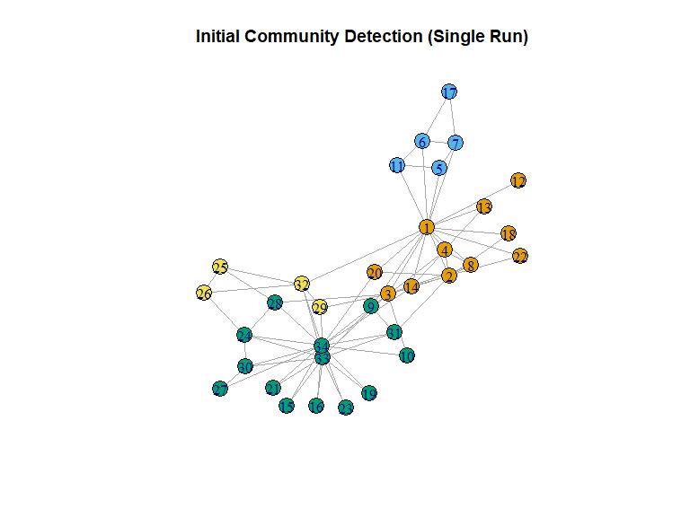

```r
# Visualize initial result
set.seed(42)
plot(karate_graph,
     vertex.label = V(karate_graph)$name,
     vertex.size = 10,
     vertex.color = membership(initial_communities),
     main = "Initial Community Detection (Single Run)",
     layout = layout_with_fr(karate_graph))
```

**Question**: Is this the only valid community structure? Let’s explore the solution space!

## Step 3: Explore the Solution Space

The key insight: running the algorithm multiple times may reveal different equally-valid solutions.

```r
# Explore solution space with multiple trials
karate_solution_space <- solutions_space_DM(
  g = karate_graph,
  n_trials = 200,
  met = "LV",  # Louvain algorithm
  precision_threshold = 0.05,  # Precision threshold
  confidence = 0.95,
  verbose = FALSE)

# Solution space summary
cat("\nSolution Space Exploration Results:\n")
```

```
#>
#> Solution Space Exploration Results:
```

```r
cat("Total trials:", karate_solution_space$log$stop_trial, "\n")
```

```
#> Total trials: 200
```

```r
cat("Stopping reason:", karate_solution_space$log$stop_reason, "\n")
```

```
#> Stopping reason: trial_budget_exhausted
```

```r
cat("Number of distinct solutions found:", ncol(karate_solution_space$partitions), "\n")
```

```
#> Number of distinct solutions found: 12
```

```r
cat("Solution space type:", solution_space_type(karate_solution_space), "\n")
```

```
#> Solution space type: Multiple
```

## Step 4: Understand Multiple Solutions

The exploration revealed multiple distinct solutions! Let’s examine them:

```r
# Display solution probabilities
cat("\nPosterior Probabilities of Each Solution:\n")
```

```
#>
#> Posterior Probabilities of Each Solution:
```

```r
print(karate_solution_space$probabilities)
```

```
#>     id count        phat        pmin       pmax
#> 1  s01    55 0.264150943 0.207137427 0.32537870
#> 4  s04    49 0.235849057 0.181290202 0.29512719
#> 3  s03    38 0.183962264 0.134860265 0.23870837
#> 5  s05    33 0.160377358 0.114247496 0.21257091
#> 2  s02    10 0.051886792 0.026308439 0.08542904
#> 9  s09     4 0.023584906 0.007738010 0.04782444
#> 6  s06     3 0.018867925 0.005188803 0.04098657
#> 11 s11     3 0.018867925 0.005188803 0.04098657
#> 10 s10     2 0.014150943 0.002941748 0.03381892
#> 7  s07     1 0.009433962 0.001149980 0.02612160
#> 8  s08     1 0.009433962 0.001149980 0.02612160
#> 12 s12     1 0.009433962 0.001149980 0.02612160
```

```r
cat("\nInterpretation:\n")
```

```
#>
#> Interpretation:
```

```r
cat("- Each solution has a posterior probability (phat)\n")
```

```
#> - Each solution has a posterior probability (phat)
```

```r
cat("- Credible intervals (pmin, pmax) quantify uncertainty\n")
```

```
#> - Credible intervals (pmin, pmax) quantify uncertainty
```

```r
cat("- Higher probability = more frequently discovered = potentially more stable\n")
```

```
#> - Higher probability = more frequently discovered = potentially more stable
```

### Visualize Solution Evolution

See how solutions emerge and stabilize over trials:

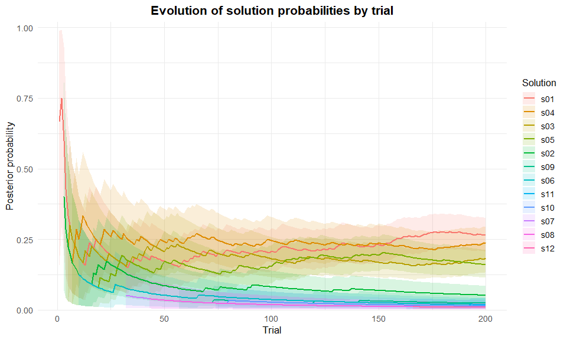

```r
plot_sol_space_evolution(karate_solution_space, show_ci = TRUE, smooth = FALSE)
```

### Quality Check

Are all solutions valid?

```r
# Check solution quality
qc_results <- quality_check(karate_graph, karate_solution_space)

cat("\nQuality Check Results:\n")
```

```
#>
#> Quality Check Results:
```

```r
print(qc_results)
```

```
#> # A tibble: 12 × 7
#>    solution_id     k modularity    mu int_conn valid reason
#>          <int> <dbl>      <dbl> <dbl> <lgl>    <lgl> <chr>
#>  1           1     4      0.419 0.269 TRUE     TRUE  ""
#>  2           2     4      0.420 0.269 TRUE     TRUE  ""
#>  3           3     4      0.416 0.244 TRUE     TRUE  ""
#>  4           4     4      0.415 0.244 TRUE     TRUE  ""
#>  5           5     4      0.395 0.333 TRUE     TRUE  ""
#>  6           6     4      0.392 0.308 TRUE     TRUE  ""
#>  7           7     4      0.394 0.308 TRUE     TRUE  ""
#>  8           8     4      0.397 0.333 TRUE     TRUE  ""
#>  9           9     4      0.398 0.333 TRUE     TRUE  ""
#> 10          10     4      0.398 0.333 TRUE     TRUE  ""
#> 11          11     4      0.395 0.308 TRUE     TRUE  ""
#> 12          12     4      0.398 0.333 TRUE     TRUE  ""
```

### Visualize All Solutions

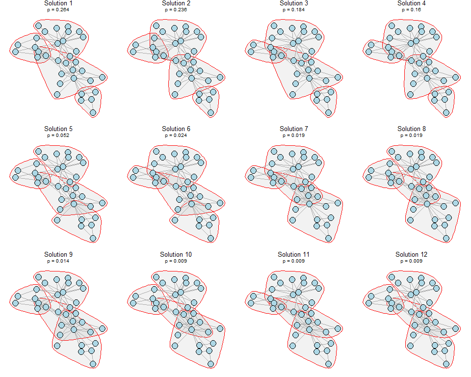

```r
# Plot all solutions side by side
plot_solutions(karate_graph, karate_solution_space,
               add_node_labels = FALSE,
               add_prob_labels = TRUE,
               add_title = TRUE)
```

## Step 5: Build Community Networks for Each Solution

Now the key question: **How do communities relate to each other in each solution?**

We’ll use `make_community_network()` to create a meta-network for each solution, where: - Each **node** = a community - Each **edge** = connections between communities - **Node size** = community size - **Edge weight** = number of inter-community connections

```r
# Get number of solutions
n_solutions <- ncol(karate_solution_space$partitions)

# Store community networks
community_networks <- list()

cat("Building community networks for each solution...\n\n")
```

```
#> Building community networks for each solution...
```

```r
# Build community network for each solution
for (i in seq_len(n_solutions)) {
  # Extract membership for this solution
  membership_i <- karate_solution_space$partitions[, i]

  # Assign to graph vertices
  V(karate_graph)$community <- membership_i

  # Build the meta-network
  community_networks[[i]] <- make_community_network(karate_graph)

  # Summary for this solution
  cat(sprintf("Solution %d (probability = %.3f):\n",
              i, karate_solution_space$probabilities$phat[i]))
  cat(sprintf("  • Number of communities: %d\n",
              vcount(community_networks[[i]])))
  cat(sprintf("  • Inter-community links: %d\n",
              ecount(community_networks[[i]])))
  cat(sprintf("  • Community sizes: %s\n",
              paste(V(community_networks[[i]])$size, collapse = ", ")))
  cat(sprintf("  • Largest community: %d members\n",
              max(V(community_networks[[i]])$size)))
  cat(sprintf("  • Smallest community: %d members\n\n",
              min(V(community_networks[[i]])$size)))
}
```

```
#> Solution 1 (probability = 0.264):
#>   • Number of communities: 4
#>   • Inter-community links: 8
#>   • Community sizes: 6, 11, 12, 5
#>   • Largest community: 12 members
#>   • Smallest community: 5 members
#>
#> Solution 2 (probability = 0.236):
#>   • Number of communities: 4
#>   • Inter-community links: 8
#>   • Community sizes: 6, 12, 11, 5
#>   • Largest community: 12 members
#>   • Smallest community: 5 members
#>
#> Solution 3 (probability = 0.184):
#>   • Number of communities: 4
#>   • Inter-community links: 9
#>   • Community sizes: 13, 12, 5, 4
#>   • Largest community: 13 members
#>   • Smallest community: 4 members
#>
#> Solution 4 (probability = 0.160):
#>   • Number of communities: 4
#>   • Inter-community links: 9
#>   • Community sizes: 4, 11, 14, 5
#>   • Largest community: 14 members
#>   • Smallest community: 4 members
#>
#> Solution 5 (probability = 0.052):
#>   • Number of communities: 4
#>   • Inter-community links: 10
#>   • Community sizes: 10, 6, 11, 7
#>   • Largest community: 11 members
#>   • Smallest community: 6 members
#>
#> Solution 6 (probability = 0.024):
#>   • Number of communities: 4
#>   • Inter-community links: 11
#>   • Community sizes: 10, 13, 4, 7
#>   • Largest community: 13 members
```

[output cut: 28 more lines]

```
#>   • Smallest community: 6 members
#>
#> Solution 11 (probability = 0.009):
#>   • Number of communities: 4
#>   • Inter-community links: 12
#>   • Community sizes: 13, 9, 4, 8
#>   • Largest community: 13 members
#>   • Smallest community: 4 members
#>
#> Solution 12 (probability = 0.009):
#>   • Number of communities: 4
#>   • Inter-community links: 11
#>   • Community sizes: 11, 9, 8, 6
#>   • Largest community: 11 members
#>   • Smallest community: 6 members
```

### Visualize Community Networks

Each row shows two graphs side by side: the original network (left) and its community meta-network (right):

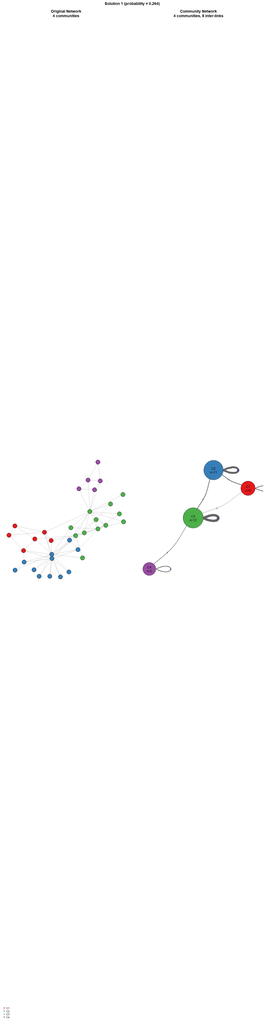

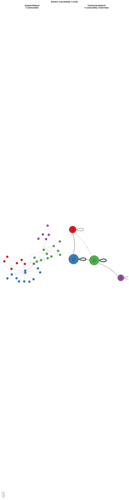

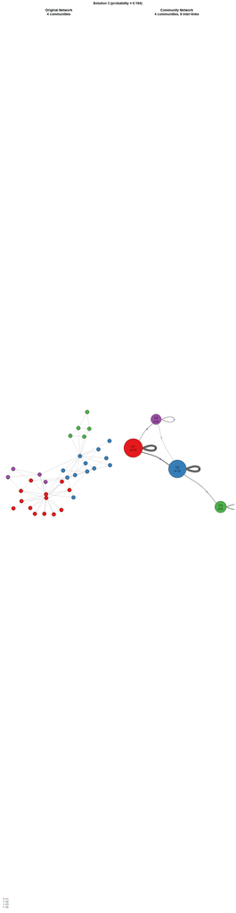

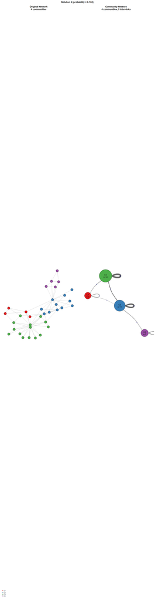

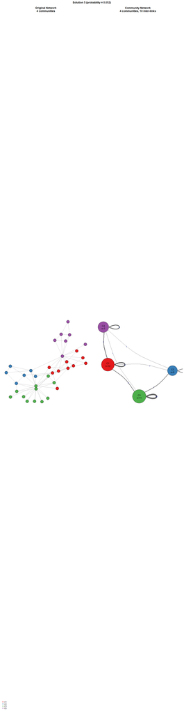

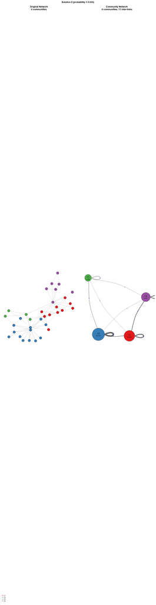

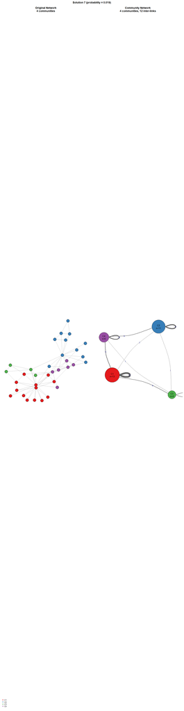

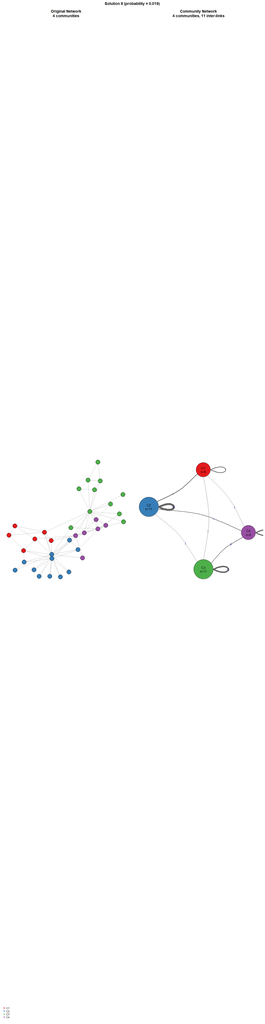

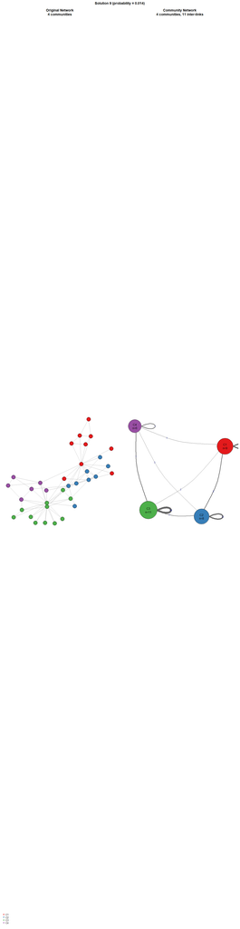

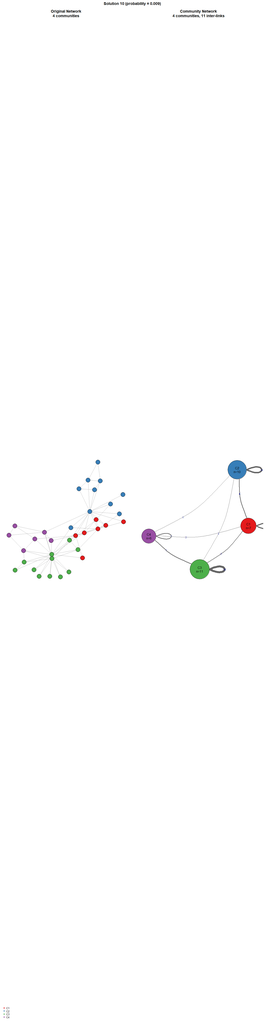

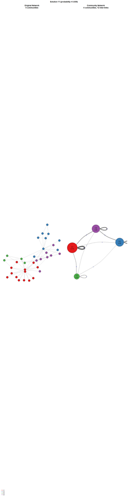

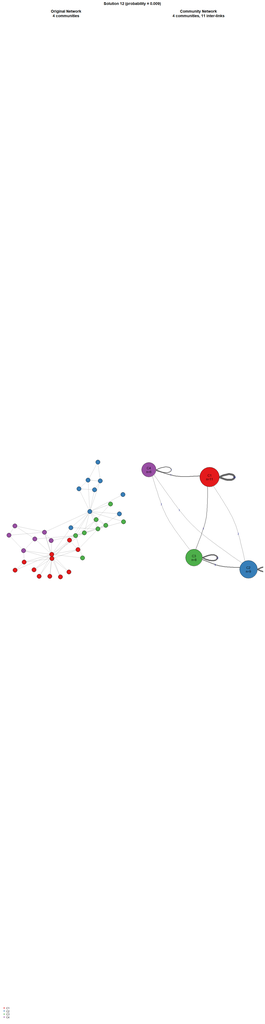

```r
# Color palette for communities
comm_colors <- c("#E41A1C", "#377EB8", "#4DAF4A", "#984EA3",
                 "#FF7F00", "#FFFF33", "#A65628", "#F781BF")

# Compute consistent layout for original network
set.seed(42)
original_layout <- layout_with_fr(karate_graph)

# Create separate figure for each solution
for (i in seq_len(n_solutions)) {
  # Set up 1x2 plotting area for this solution
  par(mfrow = c(1, 2), mar = c(1, 0.5, 3, 0.5), oma = c(0, 0, 2, 0))

  # Get membership for this solution
  membership_i <- karate_solution_space$partitions[, i]

  # Assign colors based on community membership
  node_colors <- comm_colors[membership_i]

  # === LEFT: Original Network with Communities Highlighted ===
  plot(karate_graph,
       vertex.label = NA,
       vertex.size = 8,
       vertex.color = node_colors,
       vertex.frame.color = "black",
       edge.color = "gray70",
       edge.width = 0.8,
       layout = original_layout,
       main = sprintf("Original Network\n%d communities",
                      max(membership_i)))

  # Add legend
  legend("bottomleft",
         legend = paste("C", seq_len(max(membership_i)), sep = ""),
         col = comm_colors[seq_len(max(membership_i))],
         pch = 19,
         bty = "n",
         cex = 0.8)

  # === RIGHT: Community Meta-Network ===
  gc <- community_networks[[i]]

  # Assign colors to meta-network nodes
  V(gc)$color <- comm_colors[as.numeric(V(gc)$name)]

  # Create layout for meta-network
  if (vcount(gc) <= 2) {
    layout_coords <- layout_in_circle(gc)
  } else {
    layout_coords <- layout_nicely(gc)
  }

  # Plot meta-network
  plot(gc,
       vertex.label = paste0("C", V(gc)$name, "\nn=", V(gc)$size),
       vertex.size = sqrt(V(gc)$size) * 12,
       vertex.color = V(gc)$color,
       vertex.frame.color = "black",
       vertex.label.color = "black",
       vertex.label.cex = 1.0,
       vertex.label.family = "sans",
       edge.width = E(gc)$weight / 2,
       edge.color = "gray40",
       edge.curved = 0.2,
       edge.label = E(gc)$weight,
       edge.label.cex = 0.8,
       main = sprintf("Community Network\n%d communities, %d inter-links",
                      vcount(gc),
                      ecount(gc)))

  # Add overall title
  mtext(sprintf("Solution %d (probability = %.3f)",
                i,
                karate_solution_space$probabilities$phat[i]),
        outer = TRUE, cex = 1.2, font = 2, line = 0.5)
}
```

```r
# Reset plotting parameters
par(mfrow = c(1, 1), mar = c(5, 4, 4, 2) + 0.1, oma = c(0, 0, 0, 0))
```

**Reading the plots:** - **Left panels**: Original karate club network with nodes colored by community - **Right panels**: Simplified meta-network where each node represents a community - **Node size** (right): Proportional to community size - **Edge labels** (right): Number of connections between communities

## Step 6: Compare Community Network Structures

How do the meta-networks differ across solutions?

```r
# Create comparison table
comparison_df <- data.frame(
  solution = seq_len(n_solutions),
  probability = round(karate_solution_space$probabilities$phat, 3),
  n_communities = sapply(community_networks, vcount),
  inter_links = sapply(community_networks, ecount),
  avg_size = round(sapply(community_networks, function(gc) mean(V(gc)$size)), 1),
  max_size = sapply(community_networks, function(gc) max(V(gc)$size)),
  min_size = sapply(community_networks, function(gc) min(V(gc)$size)),
  density = round(sapply(community_networks, edge_density), 3)
)

cat("\nCommunity Network Comparison:\n")
```

```
#>
#> Community Network Comparison:
```

```r
print(comparison_df)
```

```
#>    solution probability n_communities inter_links avg_size max_size min_size
#> 1         1       0.264             4           8      8.5       12        5
#> 2         2       0.236             4           8      8.5       12        5
#> 3         3       0.184             4           9      8.5       13        4
#> 4         4       0.160             4           9      8.5       14        4
#> 5         5       0.052             4          10      8.5       11        6
#> 6         6       0.024             4          11      8.5       13        4
#> 7         7       0.019             4          12      8.5       13        4
#> 8         8       0.019             4          11      8.5       11        6
#> 9         9       0.014             4          11      8.5       11        6
#> 10       10       0.009             4          11      8.5       11        6
#> 11       11       0.009             4          12      8.5       13        4
#> 12       12       0.009             4          11      8.5       11        6
#>    density
#> 1    1.333
#> 2    1.333
#> 3    1.500
#> 4    1.500
#> 5    1.667
#> 6    1.833
#> 7    2.000
#> 8    1.833
#> 9    1.833
#> 10   1.833
#> 11   2.000
#> 12   1.833
```

```r
cat("\nKey Insights:\n")
```

```
#>
#> Key Insights:
```

```r
cat("- Different solutions partition the network differently\n")
```

```
#> - Different solutions partition the network differently
```

```r
cat("- Community network density shows how interconnected communities are\n")
```

```
#> - Community network density shows how interconnected communities are
```

```r
cat("- Higher density = more mixing between communities\n")
```

```
#> - Higher density = more mixing between communities
```

```r
cat("- Lower density = more separated communities\n")
```

```
#> - Lower density = more separated communities
```

### Analyze Inter-Community Connectivity

```r
# Extract connectivity patterns for each solution
connectivity_stats <- lapply(seq_len(n_solutions), function(i) {
  gc <- community_networks[[i]]

  if (ecount(gc) > 0) {
    edges_df <- data.frame(
      from = ends(gc, E(gc))[, 1],
      to = ends(gc, E(gc))[, 2],
      weight = E(gc)$weight
    )

    data.frame(
      solution = i,
      from_comm = edges_df$from,
      to_comm = edges_df$to,
      weight = edges_df$weight,
      probability = karate_solution_space$probabilities$phat[i]
    )
  } else {
    NULL
  }
}) %>%
  bind_rows()

cat("\nInter-Community Connection Details:\n")
```

```
#>
#> Inter-Community Connection Details:
```

```r
print(connectivity_stats)
```

```
#>     solution from_comm to_comm weight probability
#> 1          1         1       1      7 0.264150943
#> 2          1         1       2      7 0.264150943
#> 3          1         2       2     20 0.264150943
#> 4          1         1       3      3 0.264150943
#> 5          1         2       3      7 0.264150943
#> 6          1         3       3     24 0.264150943
#> 7          1         3       4      4 0.264150943
#> 8          1         4       4      6 0.264150943
#> 9          2         1       1      7 0.235849057
#> 10         2         1       2      7 0.235849057
#> 11         2         2       2     21 0.235849057
#> 12         2         1       3      3 0.235849057
#> 13         2         2       3      7 0.235849057
#> 14         2         3       3     23 0.235849057
```

[output cut: 109 more lines]

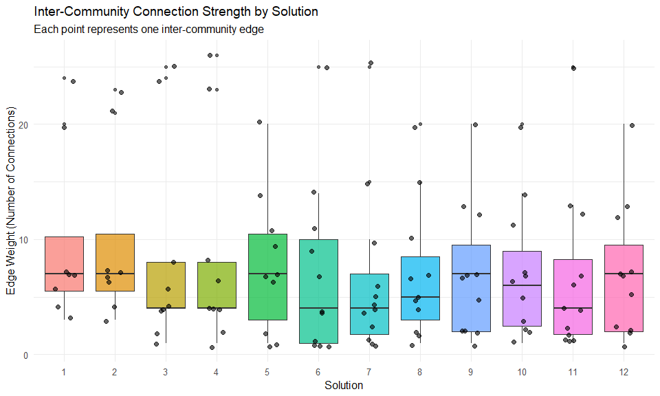

```r
# Visualize connection strength distribution
if (nrow(connectivity_stats) > 0 && n_solutions > 1) {
  ggplot(connectivity_stats, aes(x = factor(solution), y = weight)) +
    geom_boxplot(aes(fill = factor(solution)), alpha = 0.7) +
    geom_jitter(width = 0.2, alpha = 0.6, size = 2) +
    labs(
      title = "Inter-Community Connection Strength by Solution",
      subtitle = "Each point represents one inter-community edge",
      x = "Solution",
      y = "Edge Weight (Number of Connections)",
      fill = "Solution"
    ) +
    theme_minimal(base_size = 12) +
    theme(legend.position = "none")
} else {
  cat("\nInsufficient data for connectivity comparison plot.\n")
}
```

### Network Compression Analysis

How much simpler is the community network compared to the original?

```r
# Calculate compression metrics
compression_df <- data.frame(
  solution = seq_len(n_solutions),
  original_nodes = vcount(karate_graph),
  community_nodes = sapply(community_networks, vcount),
  compression_ratio = round(sapply(community_networks, vcount) / vcount(karate_graph), 2),
  original_edges = ecount(karate_graph),
  community_edges = sapply(community_networks, ecount),
  edge_reduction = round(1 - sapply(community_networks, ecount) / ecount(karate_graph), 2)
)

cat("\nNetwork Compression Through Community Aggregation:\n")
```

```
#>
#> Network Compression Through Community Aggregation:
```

```r
print(compression_df)
```

```
#>    solution original_nodes community_nodes compression_ratio original_edges
#> 1         1             34               4              0.12             78
#> 2         2             34               4              0.12             78
#> 3         3             34               4              0.12             78
#> 4         4             34               4              0.12             78
#> 5         5             34               4              0.12             78
#> 6         6             34               4              0.12             78
#> 7         7             34               4              0.12             78
#> 8         8             34               4              0.12             78
#> 9         9             34               4              0.12             78
#> 10       10             34               4              0.12             78
#> 11       11             34               4              0.12             78
#> 12       12             34               4              0.12             78
#>    community_edges edge_reduction
#> 1                8           0.90
#> 2                8           0.90
#> 3                9           0.88
#> 4                9           0.88
#> 5               10           0.87
#> 6               11           0.86
#> 7               12           0.85
#> 8               11           0.86
#> 9               11           0.86
#> 10              11           0.86
#> 11              12           0.85
#> 12              11           0.86
```

```r
cat("\nInterpretation:\n")
```

```
#>
#> Interpretation:
```

```r
cat("- Compression ratio: smaller = more compression\n")
```

```
#> - Compression ratio: smaller = more compression
```

```r
cat("- Edge reduction: proportion of edges removed in meta-network\n")
```

```
#> - Edge reduction: proportion of edges removed in meta-network
```

```r
cat("- Community networks are simpler, higher-level representations\n")
```

```
#> - Community networks are simpler, higher-level representations
```

## Key Takeaways

1. **Multiple Valid Solutions**: Community detection often has multiple plausible partitions, not just one “correct” answer
2. **Solution Space Exploration**: Running many trials reveals the diversity and stability of solutions
3. **Uncertainty Quantification**: Posterior probabilities tell us which solutions are most reproducible
4. **Meta-Network Analysis**: `make_community_network()` creates simplified views showing how communities relate, useful for:
   - Understanding high-level structure
   - Identifying boundary regions
   - Comparing solutions
   - Simplifying large networks
5. **Different Perspectives**: Each solution may emphasize different structural aspects of the same network

## Next Steps

Try this workflow on your own networks! The approach is especially valuable for: - Large networks where visual inspection is difficult - Networks with ambiguous community structure - Situations requiring robust, reproducible results - Hierarchical or multi-scale analysis